# Coding Assignment 3

## Question 5

Use the 30 withheld observations and calculate the performance measures for your best two models. Which is the better model? (remember that “better” depends on whether your outlook is short or long run)

```r
pred1=predict(model1,newdata=test)
pred2=exp(predict(model2,newdata=test))
rmse1=sqrt(mean((test$Charges-pred1)^2))
rmse2=sqrt(mean((test$Charges-pred2)^2))
rmse1
```

```
## [1] 4819.255
```

```r
rmse2
```

```
## [1] 6509.786
```

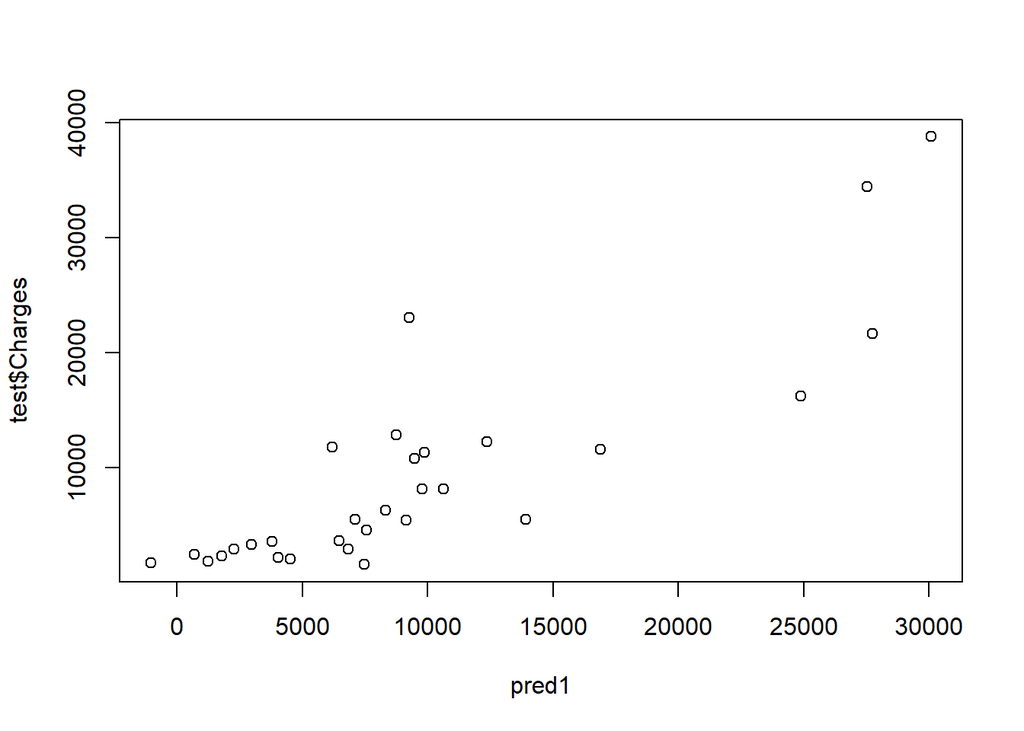

```r
plot(pred1,test$Charges)
```

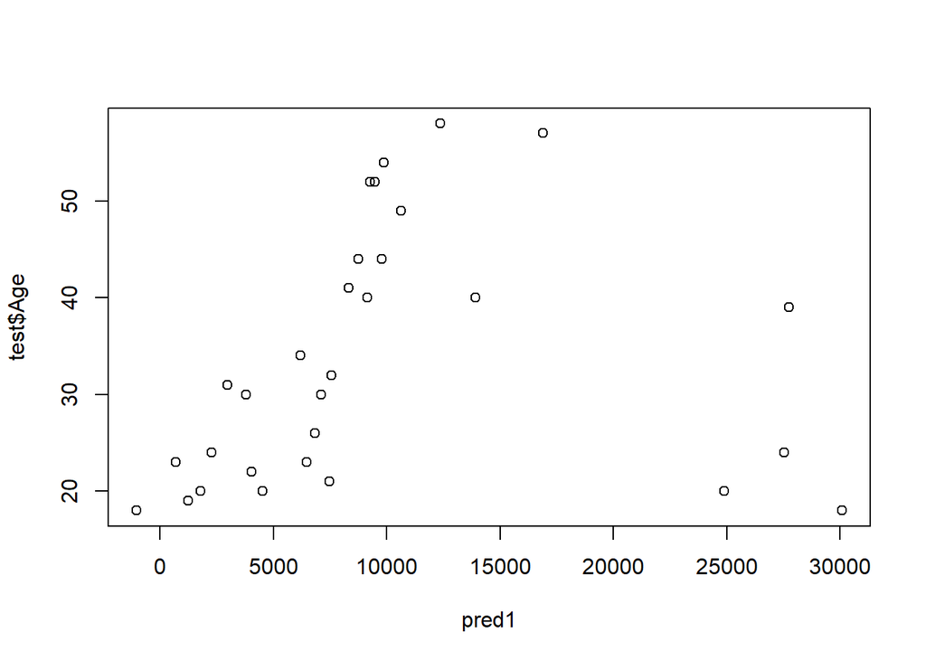

```r
plot(pred1,test$Age)
```

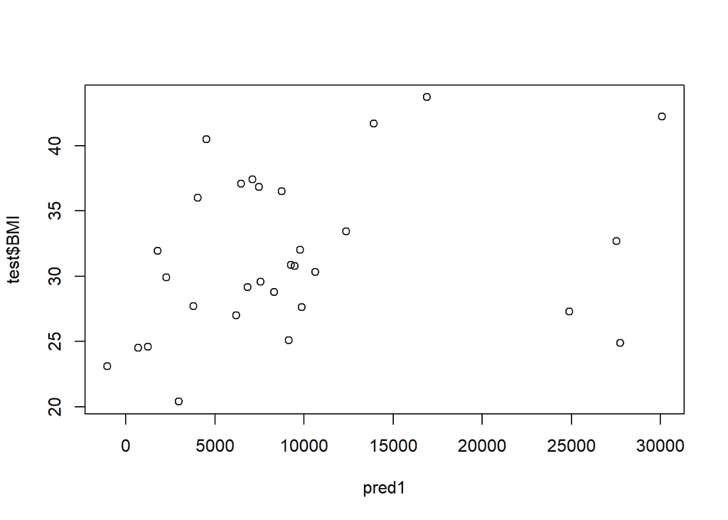

```r
plot(pred1,test$BMI)
```

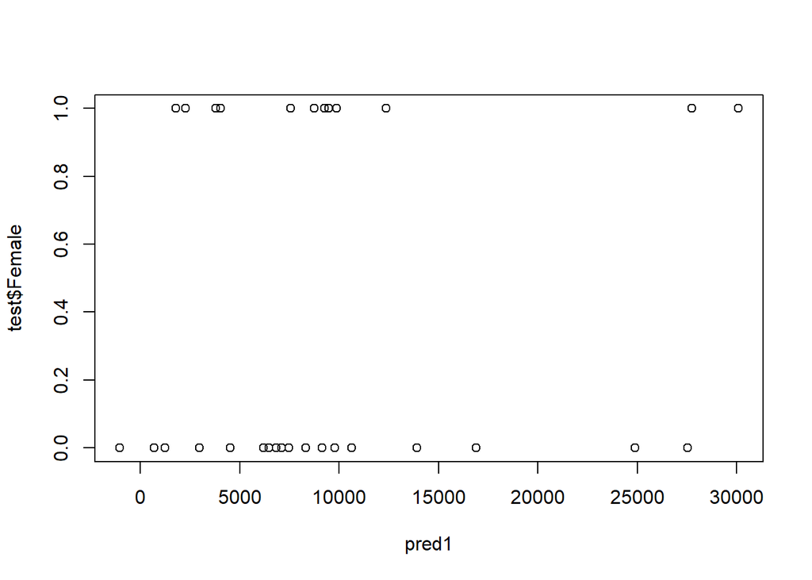

```r
plot(pred1,test$Female)
```

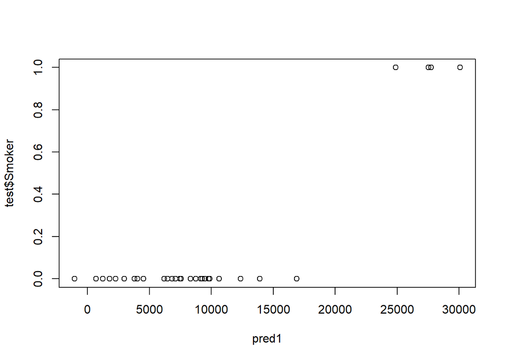

```r
plot(pred1,test$Smoker)
```

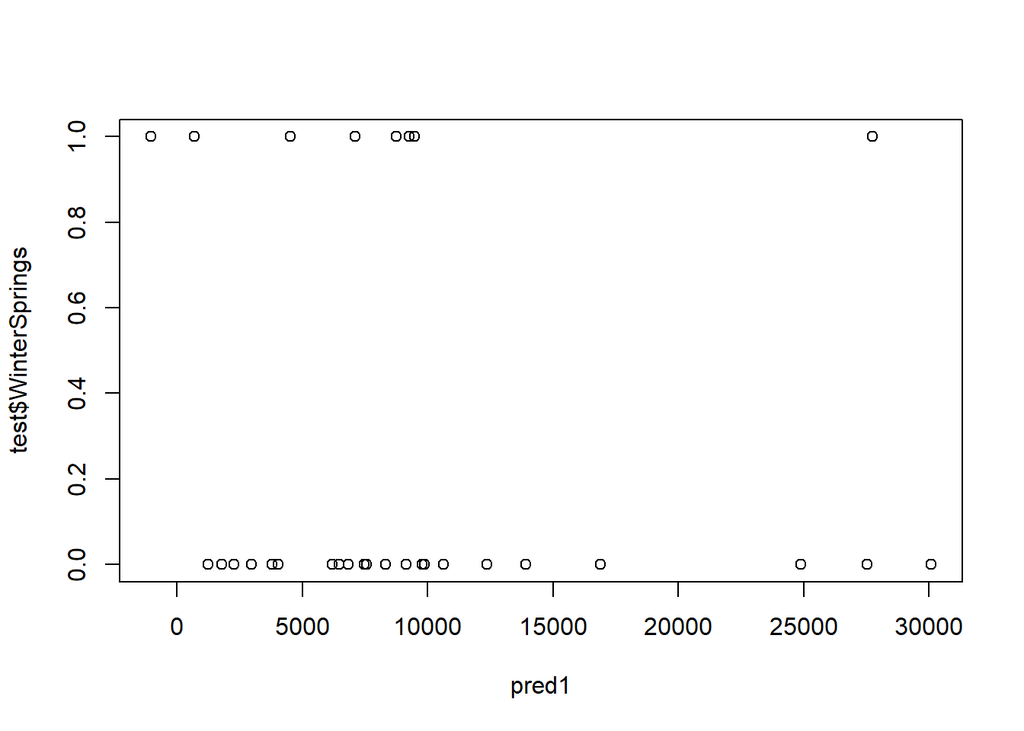

```r
plot(pred1,test$WinterSprings)
```

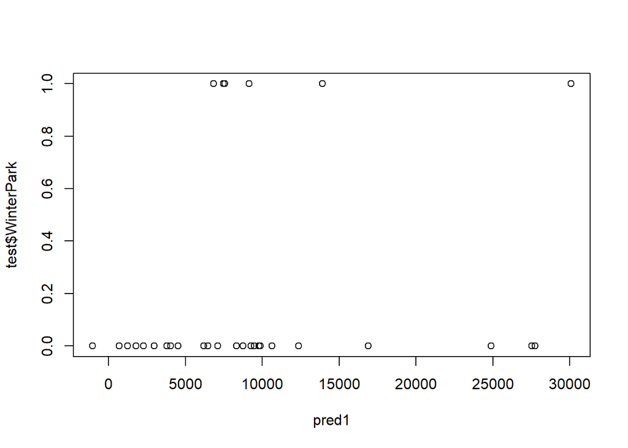

```r
plot(pred1,test$WinterPark)
```

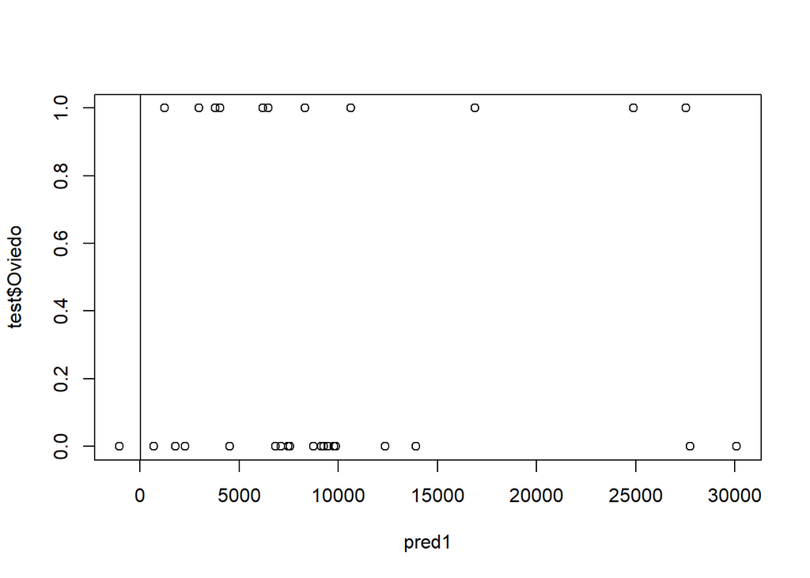

```r
plot(pred1,test$Oviedo)
abline(model1)
```

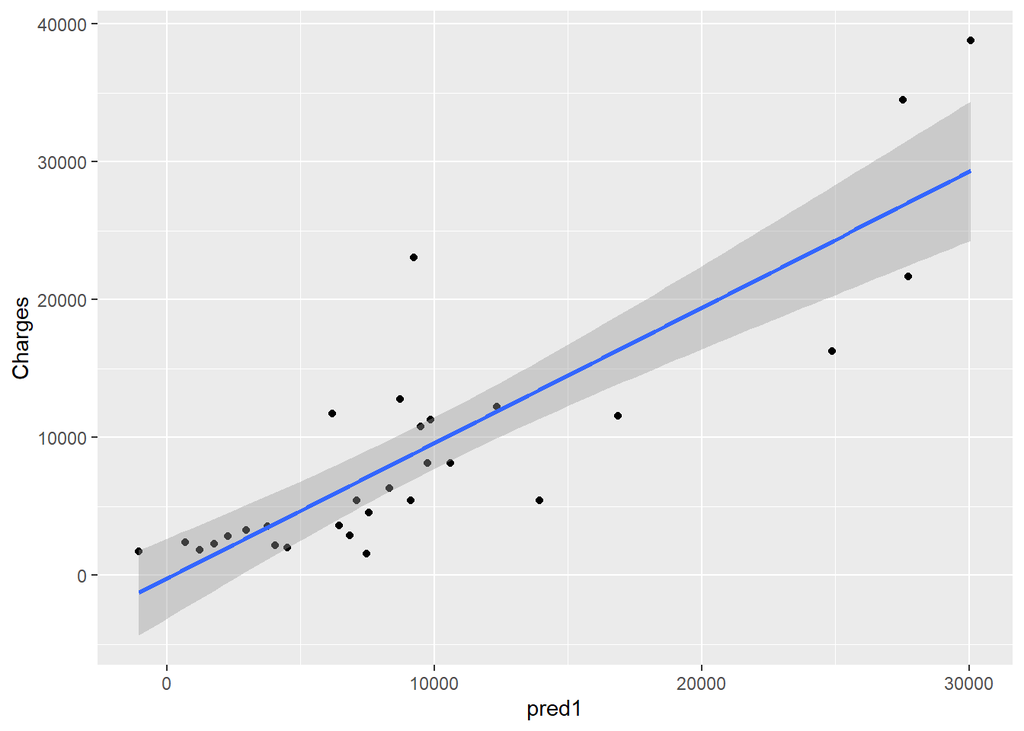

```r
results_df=data.frame(pred1=pred1,pred2=pred2,Charges=test$Charges)
ggplot(data=results_df,mapping = aes(x=pred1,y=Charges))+
  geom_point()+
  geom_smooth(method = "lm")
```

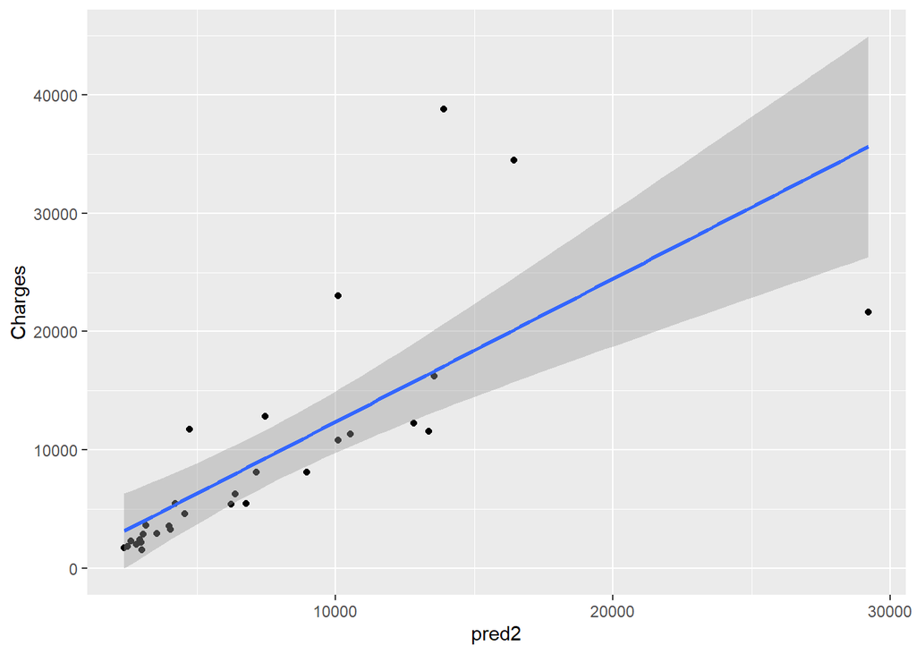

```r
ggplot(data=results_df,mapping = aes(x=pred2,y=Charges))+
  geom_point()+
  geom_smooth(method = "lm")
```

## Question 6

Provide interpretations of the coefficients, do the signs make sense? Perform marginal change analysis (thing 2) on the independent variables.

```r
summary(model2)
```

```
##
## Call:
## lm(formula = log(Charges) ~ . - Children, data = samp)
##
## Residuals:
##     Min      1Q  Median      3Q     Max
## -0.8687 -0.1599  0.0202  0.1150  0.9510
##
## Coefficients:
##                Estimate Std. Error t value Pr(>|t|)
## (Intercept)    6.885183   0.246899  27.887   <2e-16 ***
## Age            0.041515   0.002935  14.144   <2e-16 ***
## BMI            0.005099   0.006639   0.768    0.445
## Female        -0.005248   0.084162  -0.062    0.950
## Smoker         1.633109   0.107495  15.192   <2e-16 ***
## WinterSprings  0.023453   0.115059   0.204    0.839
## WinterPark     0.063946   0.133902   0.478    0.635
## Oviedo         0.026083   0.115490   0.226    0.822
## ---
## Signif. codes:  0 '***' 0.001 '**' 0.01 '*' 0.05 '.' 0.1 ' ' 1
##
## Residual standard error: 0.3431 on 62 degrees of freedom
## Multiple R-squared:  0.8701, Adjusted R-squared:  0.8554
## F-statistic: 59.32 on 7 and 62 DF,  p-value: < 2.2e-16
```

## Question 7

An eager insurance representative comes back with five potential clients. Using the better of the two models selected above, provide the prediction intervals for the five potential clients using the information provided by the insurance rep.

| Customer | Age | BMI | Female | Children | Smoker | City |
| --- | --- | --- | --- | --- | --- | --- |
| 1 | 60 | 22 | 1 | 0 | 0 | Oviedo |
| 2 | 40 | 30 | 0 | 1 | 0 | Sanford |
| 3 | 25 | 25 | 0 | 0 | 1 | Winter Park |
| 4 | 33 | 35 | 1 | 2 | 0 | Winter Springs |
| 5 | 45 | 27 | 1 | 3 | 0 | Oviedo |

```r
predictiondf=data.frame(
 customer=1:5,
 Age=c(60,40,25,33,45),
 BMI=c(22,30,25,35,27),
 Female=c(1,0,0,1,1),
 Children=c(0,1,0,2,3),
 Smoker=c(0,0,1,0,0),
 WinterSprings=c(0,0,0,1,0),
 WinterPark=c(0,0,1,0,0),
 Oviedo=c(1,0,0,0,1)
)
pred_new=predict(model2,newdata=predictiondf,interval="prediction",level=0.95)
exp(pred_new)
```

```
##         fit      lwr       upr
## 1 13481.409 6509.769 27919.327
## 2  5995.278 2938.825 12230.520
## 3 17112.573 8159.377 35890.015
## 4  4683.606 2295.299  9556.997
## 5  7419.303 3646.373 15096.114
```

## Question 8

The owner notices that some of the predictions are wider than others, explain why. In this case, the owner will notice heteroscedasticity in the model and prediction intervals will be wider as the independent variables that are further away from their means causes a wider variance.So, prediction intervals will have wider intervals.

## Question 9

Are there any prediction problems that occur with the five potential clients? If so, explain.